# Shiverer Optic Nerve Diameter

Matt Nolan & Jenea Bin

2025-10-28

# Goals

We have a dataset that contains diameters of axons in the optic nerve of wt and shiverer mice, calculated from cross-sectional area (assuming circular). We’d like to know if the mean axon diameter, or the distribution of axon diameters, differs between groups. We want to implement tests that take account of within and between animal variance.

# Load and format data

```r
df <- read_excel("Shiverer-ON-AxonDiameter.xlsx", range = "A1:I295") %>%
    pivot_longer(cols = 1:9) %>%
    drop_na() %>%
    mutate(group = as_factor(ifelse(name %in% c("C149-4555", "C149-4567", "C149-4591", "C149-4593"), "control", "mutant")))

df$group <- as.factor(df$group)
df$name <- as.factor(df$name)
```

# Plot the data

Plot of individual mice, colour coded by group.

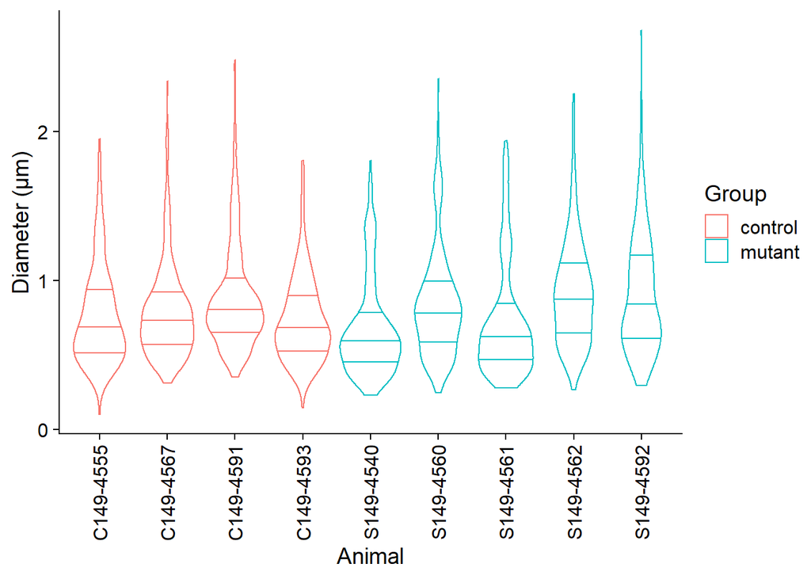

```r
(plot_by_id <- ggplot(data = df, aes(name, value)) +
     geom_violin(aes(colour = group), draw_quantiles = c(0.25, 0.5, 0.75)) +
     theme_cowplot(font_size = 14) +
     theme(axis.text.x = element_text(angle = 90, vjust = 0.5, hjust=1)) +
    labs(x = 'Animal', y = 'Diameter (µm)', colour = "Group"))
```

```r
#ggsave('Plots/violins.jpeg', plot_by_id)
```

# Descriptive Statistics per animal

```r
# Compute 25th, 50th, and 75th percentiles per animal
df_summary <- df %>%
  group_by(group, name) %>%
  summarise(
    mean = mean(value, na.rm = TRUE),
    median = median(value, na.rm = TRUE),
    q25 = quantile(value, 0.25, na.rm = TRUE),
    q75 = quantile(value, 0.75, na.rm = TRUE),
    sd = sd(value, na.rm = TRUE),
    .groups = "drop"
  )

df_summary
```

```
## # A tibble: 9 x 7
##   group   name       mean median   q25   q75    sd
##   <fct>   <fct>     <dbl>  <dbl> <dbl> <dbl> <dbl>
## 1 control C149-4555 0.764  0.676 0.515 0.938 0.330
## 2 control C149-4567 0.792  0.724 0.572 0.901 0.321
## 3 control C149-4591 0.893  0.810 0.674 0.989 0.367
## 4 control C149-4593 0.738  0.674 0.524 0.886 0.288
## 5 mutant  S149-4540 0.676  0.584 0.447 0.761 0.327
## 6 mutant  S149-4560 0.841  0.798 0.591 0.978 0.362
## 7 mutant  S149-4561 0.724  0.616 0.458 0.811 0.381
## 8 mutant  S149-4562 0.919  0.887 0.646 1.11  0.355
## 9 mutant  S149-4592 0.907  0.809 0.607 1.14  0.392
```

# Visualization of quantile data:

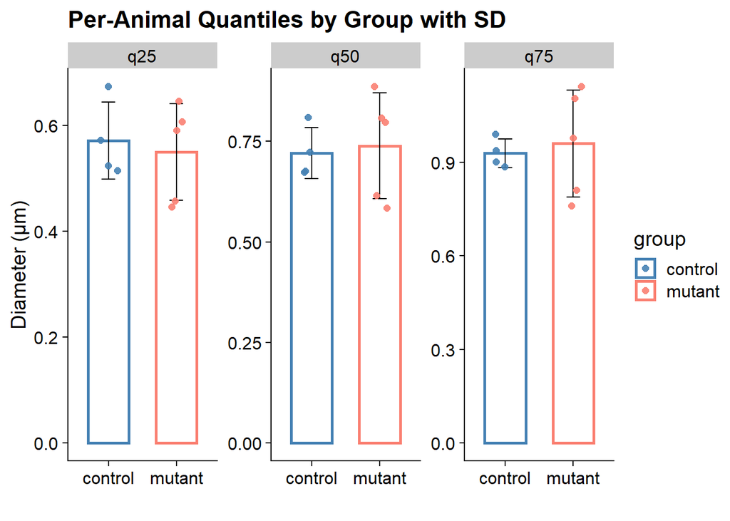

```r
df_quant <- df %>%
  group_by(name, group) %>%
  summarise(
    q25 = quantile(value, 0.25),
    q50 = quantile(value, 0.5),
    q75 = quantile(value, 0.75),
    .groups = "drop"
  )

# Convert to long format for plotting
df_quant_long <- df_quant %>%
  pivot_longer(cols = q25:q75, names_to = "quantile", values_to = "value")

# Compute group-level summary: mean and SD per quantile
df_group_summary <- df_quant_long %>%
  group_by(group, quantile) %>%
  summarise(
    mean_value = mean(value),
    sd_value = sd(value),
    .groups = "drop"
  )

# Plot: outlined bars with individual points and SD
ggplot(df_group_summary, aes(x = group, y = mean_value)) +
  geom_col(aes(color = group), fill = NA, width = 0.6, size = 1) +       # outlined bars
  geom_errorbar(aes(ymin = mean_value - sd_value, ymax = mean_value + sd_value),
                width = 0.2, color = "black") +                          # SD error bars
  geom_jitter(data = df_quant_long,
              aes(x = group, y = value, color = group),
              width = 0.15, size = 2, alpha = 0.9, inherit.aes = FALSE) + # individual points
  facet_wrap(~quantile, scales = "free_y") +
  scale_color_manual(values = c("control" = "steelblue", "mutant" = "salmon")) +
  theme_cowplot() +
  labs(
    y = "Diameter (µm)",
    x = "",
    title = "Per-Animal Quantiles by Group with SD"
  )
```

# Statistical test per quantile

```r
t.test(q75 ~ group, data = df_quant)
```

```
##
##  Welch Two Sample t-test
##
## data:  q75 by group
## t = -0.38516, df = 4.7088, p-value = 0.7169
## alternative hypothesis: true difference in means between group control and group mutant is not equal to 0
## 95 percent confidence interval:
##  -0.2393949  0.1780124
## sample estimates:
## mean in group control  mean in group mutant
##             0.9287437             0.9594350
```

```r
t.test(q25 ~ group, data = df_quant)
```

```
##
##  Welch Two Sample t-test
##
## data:  q25 by group
## t = 0.38695, df = 6.9942, p-value = 0.7103
## alternative hypothesis: true difference in means between group control and group mutant is not equal to 0
## 95 percent confidence interval:
##  -0.1082911  0.1506586
## sample estimates:
## mean in group control  mean in group mutant
##             0.5710937             0.5499100
```

```r
t.test(q50 ~ group, data = df_quant)
```

```
##
##  Welch Two Sample t-test
##
## data:  q50 by group
## t = -0.26555, df = 5.995, p-value = 0.7995
## alternative hypothesis: true difference in means between group control and group mutant is not equal to 0
## 95 percent confidence interval:
##  -0.181570  0.146025
## sample estimates:
## mean in group control  mean in group mutant
##             0.7209875             0.7387600
```

The above analysis compares per-animal quantiles (25th, median, 75th) using t-tests, which summarizes each animal but ignores the hierarchical structure of the data and discards within-animal variability. Therefore, here we are using a linear mixed model to test for group differences in mean axon diameter to account for the full data structure.

# Tests for differences in means

```r
mm <- lmer(value ~ group + (1 | name), data = df)
mm_null <- lmer(value ~ (1 | name), data = df)
summary(mm)
```

```
## Linear mixed model fit by REML ['lmerMod']
## Formula: value ~ group + (1 | name)
##    Data: df
##
## REML criterion at convergence: 1725.6
##
## Scaled residuals:
##     Min      1Q  Median      3Q     Max
## -1.9090 -0.7076 -0.2229  0.4339  5.1007
##
## Random effects:
##  Groups   Name        Variance Std.Dev.
##  name     (Intercept) 0.008293 0.09107
##  Residual             0.121826 0.34904
## Number of obs: 2310, groups:  name, 9
##
## Fixed effects:
##             Estimate Std. Error t value
## (Intercept)  0.79704    0.04687  17.006
## groupmutant  0.01592    0.06283   0.253
##
## Correlation of Fixed Effects:
##             (Intr)
## groupmutant -0.746
```

```r
anova(mm, mm_null)
```

```
## refitting model(s) with ML (instead of REML)
```

```
## Data: df
## Models:
## mm_null: value ~ (1 | name)
## mm: value ~ group + (1 | name)
##         npar    AIC    BIC  logLik deviance  Chisq Df Pr(>Chisq)
## mm_null    3 1722.6 1739.8 -858.31   1716.6
## mm         4 1724.5 1747.5 -858.26   1716.5 0.0809  1     0.7761
```

Because the data is not normally distributed, the data can be log transformed. This is closer to a normal distribution.

# Analyse log transformed data

Note - Natural log, not log10

Plot of individual mice, colour coded by group.

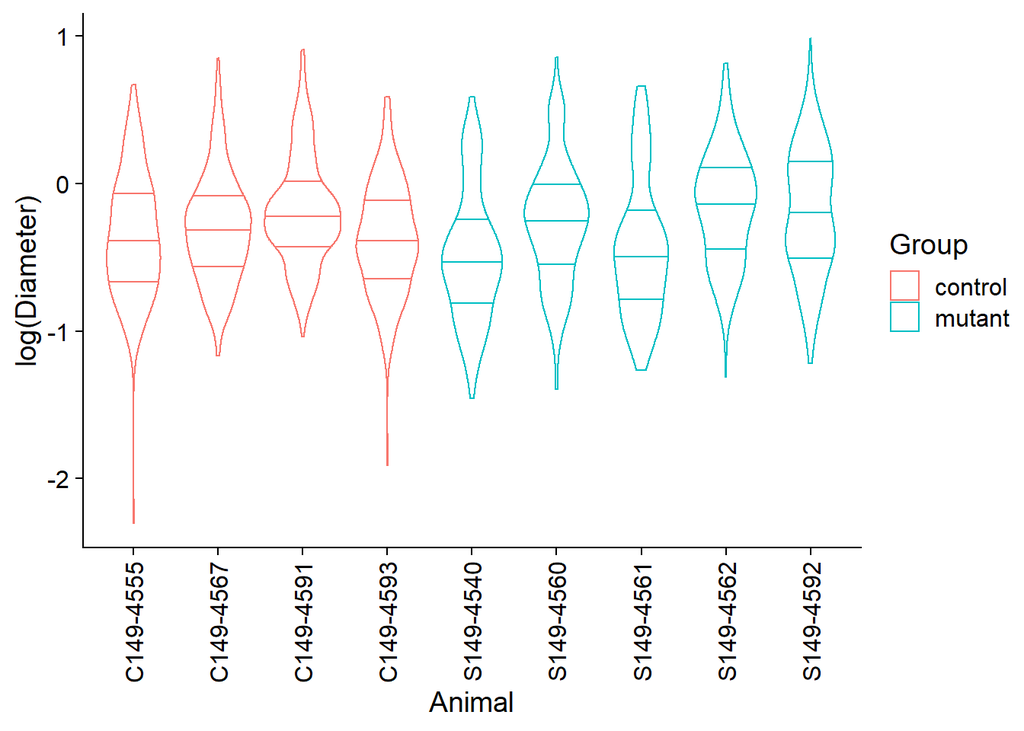

```r
(plot_by_id2 <- ggplot(data = df, aes(name, log(value))) +
     geom_violin(aes(colour = group), draw_quantiles = c(0.25, 0.5, 0.75)) +
     theme_cowplot(font_size = 14) +
     theme(axis.text.x = element_text(angle = 90, vjust = 0.5, hjust=1)) +
    labs(x = 'Animal', y = 'log(Diameter)', colour = "Group"))
```

Tests for differences in means

```r
mm_t <- lmer(log(value) ~ group + (1 | name), data = df)
mm_t_null <- lmer(log(value) ~ (1 | name), data = df)
summary(mm_t)
```

```
## Linear mixed model fit by REML ['lmerMod']
## Formula: log(value) ~ group + (1 | name)
##    Data: df
##
## REML criterion at convergence: 2442
##
## Scaled residuals:
##     Min      1Q  Median      3Q     Max
## -4.7921 -0.7012 -0.0488  0.6141  2.8938
##
## Random effects:
##  Groups   Name        Variance Std.Dev.
##  name     (Intercept) 0.01554  0.1246
##  Residual             0.16601  0.4074
## Number of obs: 2310, groups:  name, 9
##
## Fixed effects:
##              Estimate Std. Error t value
## (Intercept) -0.303916   0.063658  -4.774
## groupmutant -0.002823   0.085360  -0.033
##
## Correlation of Fixed Effects:
##             (Intr)
## groupmutant -0.746
```

```r
anova(mm_t, mm_t_null)
```

```
## refitting model(s) with ML (instead of REML)
```

```
## Data: df
## Models:
## mm_t_null: log(value) ~ (1 | name)
## mm_t: log(value) ~ group + (1 | name)
##           npar    AIC    BIC  logLik deviance  Chisq Df Pr(>Chisq)
## mm_t_null    3 2440.1 2457.4 -1217.1   2434.1
## mm_t         4 2442.1 2465.1 -1217.1   2434.1 0.0015  1     0.9689
```

# Evaluate residuals.

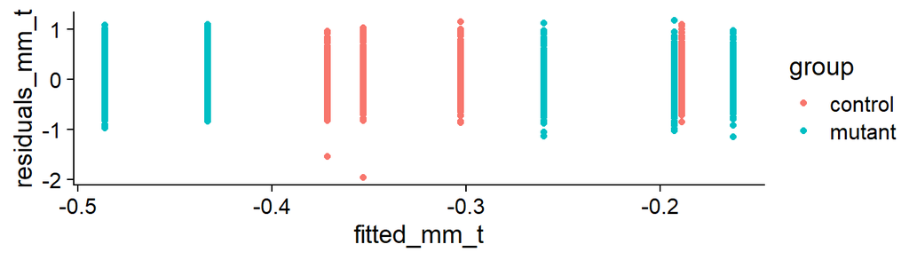

```r
df$residuals_mm_t <- resid(mm_t)
df$fitted_mm_t <- fitted(mm_t)
(res_t_plot <- ggplot(data = df, aes(x = fitted_mm_t, y = residuals_mm_t)) +
    geom_point(aes(colour = group)) +
    theme_cowplot())
```

# Check for difference in residual variance between the two groups

```r
mm_hom <- lme((value) ~ group, random = ~1 | name, data = df) #LMM that assumes equal residual variance (homoscedasticity)

mm_het <- lme((value) ~ group, random = ~1 | name, #LMM that allows different residual variances for each group (heteroscedasticity)
              weights = varIdent(form = ~1 | group),
              data = df)

anova(mm_hom, mm_het)
```

```
##        Model df      AIC      BIC    logLik   Test  L.Ratio p-value
## mm_hom     1  4 1733.583 1756.559 -862.7913
## mm_het     2  5 1725.067 1753.788 -857.5335 1 vs 2 10.51565  0.0012
```

Based on this analysis, the mm_het fits significantly better.

# Test for differences in means using heteroscedastic model

```r
summary(mm_het)
```

```
## Linear mixed-effects model fit by REML
##   Data: df
##        AIC      BIC    logLik
##   1725.067 1753.788 -857.5335
##
## Random effects:
##  Formula: ~1 | name
##         (Intercept)  Residual
## StdDev:  0.09087495 0.3295068
##
## Variance function:
##  Structure: Different standard deviations per stratum
##  Formula: ~1 | group
##  Parameter estimates:
##  control   mutant
## 1.000000 1.101921
## Fixed effects:  (value) ~ group
##                 Value  Std.Error   DF   t-value p-value
## (Intercept) 0.7970169 0.04663059 2301 17.092147  0.0000
## groupmutant 0.0159227 0.06266215    7  0.254104  0.8067
##  Correlation:
##             (Intr)
## groupmutant -0.744
##
## Standardized Within-Group Residuals:
##        Min         Q1        Med         Q3        Max
## -2.0215715 -0.7140278 -0.2235684  0.4370361  4.9043798
##
## Number of Observations: 2310
## Number of Groups: 9
```

```r
mm_het_ML <- update(mm_het, method = "ML")
mm_het_null_ML <- update(mm_het, . ~ . - group, method = "ML")

anova(mm_het_ML, mm_het_null_ML)
```

```
##                Model df      AIC      BIC    logLik   Test    L.Ratio p-value
## mm_het_ML          1  5 1716.003 1744.728 -853.0013
## mm_het_null_ML     2  4 1714.084 1737.064 -853.0421 1 vs 2 0.08151041  0.7753
```

No significant difference between control and mutant using this updated model.

Now repeat for the log transformed data.

```r
mm_t_hom <- lme(log(value) ~ group, random = ~1 | name, data = df)

mm_t_het <- lme(log(value) ~ group, random = ~1 | name,
              weights = varIdent(form = ~1 | group),
              data = df)

anova(mm_t_hom, mm_t_het)
```

```
##          Model df      AIC      BIC    logLik   Test  L.Ratio p-value
## mm_t_hom     1  4 2449.963 2472.939 -1220.981
## mm_t_het     2  5 2438.665 2467.386 -1214.333 1 vs 2 13.29746   3e-04
```

```r
summary(mm_t_het)
```

```
## Linear mixed-effects model fit by REML
##   Data: df
##        AIC      BIC    logLik
##   2438.665 2467.386 -1214.333
##
## Random effects:
##  Formula: ~1 | name
##         (Intercept)  Residual
## StdDev:   0.1243987 0.3817606
##
## Variance function:
##  Structure: Different standard deviations per stratum
##  Formula: ~1 | group
##  Parameter estimates:
##  control   mutant
## 1.000000 1.115412
## Fixed effects:  log(value) ~ group
##                   Value  Std.Error   DF   t-value p-value
## (Intercept) -0.30393907 0.06337365 2301 -4.795985  0.0000
## groupmutant -0.00281863 0.08514359    7 -0.033104  0.9745
##  Correlation:
##             (Intr)
## groupmutant -0.744
##
## Standardized Within-Group Residuals:
##         Min          Q1         Med          Q3         Max
## -5.11385412 -0.69596200 -0.05198792  0.62315667  3.01952594
##
## Number of Observations: 2310
## Number of Groups: 9
```

```r
mm_t_het_ML <- update(mm_t_het, method = "ML")
mm_t_het_null_ML <- update(mm_t_het, . ~ . - group, method = "ML")

anova(mm_t_het_ML, mm_t_het_null_ML)
```

```
##                  Model df      AIC      BIC    logLik   Test     L.Ratio
## mm_t_het_ML          1  5 2430.827 2459.552 -1210.414
## mm_t_het_null_ML     2  4 2428.829 2451.809 -1210.414 1 vs 2 0.001525741
##                  p-value
## mm_t_het_ML
## mm_t_het_null_ML  0.9688
```

# Histograms of log transformed data

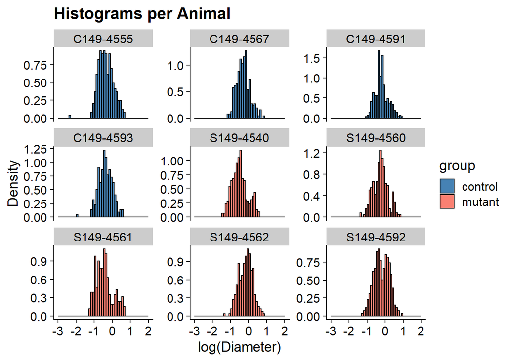

```r
# Unique animal names
names <- unique(df$name)

# Function to generate histogram tibble per animal
histfun_df <- function(name, df, submean = 0) {
  # Optionally subtract mean
  sub <- if(submean == 1) mean(df$value[df$name == name]) else 0
  # Compute histogram (log-transformed)
  h <- hist(log(df$value[df$name == name] - sub),
            breaks = seq(-3, 2, 0.1), plot = FALSE)
  # Return as tibble with group info
  tibble(mids = h$mids,
         density = h$density,
         animal = name,
         group = unique(df$group[df$name == name]))
}

# Generate all histograms and combine into one tibble
hists_tib <- map_df(names, histfun_df, df = df, submean = 0)

# Plot all histograms with faceting and coloring by group
ggplot(hists_tib, aes(x = mids, y = density, fill = group)) +
  geom_col(position = "dodge", color = "black") +
  facet_wrap(~animal, scales = "free_y") +
  theme_cowplot() +
  labs(x = "log(Diameter)", y = "Density", title = "Histograms per Animal") +
  scale_fill_manual(values = c("control" = "steelblue", "mutant" = "salmon"))
```

# Evaluate distributions

Untransformed data

```r
fit.lqmm <- lqmm(fixed = value ~ group, random = ~1, group = name, tau = c(0.25,0.5, 0.75), nK = 7, type = "normal", data = df, control = c(method = "df", LP_max_iter = 5000))
summary(fit.lqmm, R = 500, seed = 2)
```

```
## Call: lqmm(fixed = value ~ group, random = ~1, group = name, tau = c(0.25,
##     0.5, 0.75), nK = 7, type = "normal", data = df, control = c(method = "df",
##     LP_max_iter = 5000))
##
## tau = 0.25
##
## Fixed effects:
##                 Value Std. Error lower bound upper bound Pr(>|t|)
## (Intercept)  0.567003   0.030565    0.506951      0.6271   <2e-16 ***
## groupmutant -0.035167   0.052876   -0.139054      0.0687   0.5063
## ---
## Signif. codes:  0 '***' 0.001 '**' 0.01 '*' 0.05 '.' 0.1 ' ' 1
##
## tau = 0.5
##
## Fixed effects:
##                 Value Std. Error lower bound upper bound Pr(>|t|)
## (Intercept)  0.724278   0.031029    0.663314      0.7852   <2e-16 ***
## groupmutant -0.013619   0.069437   -0.150044      0.1228   0.8446
## ---
## Signif. codes:  0 '***' 0.001 '**' 0.01 '*' 0.05 '.' 0.1 ' ' 1
##
## tau = 0.75
##
## Fixed effects:
##                 Value Std. Error lower bound upper bound Pr(>|t|)
## (Intercept)  0.937302   0.023883    0.890378      0.9842   <2e-16 ***
## groupmutant  0.077811   0.075548   -0.070621      0.2262   0.3035
## ---
## Signif. codes:  0 '***' 0.001 '**' 0.01 '*' 0.05 '.' 0.1 ' ' 1
##
## AIC:
## [1] 1293 (df = 4) 1756 (df = 4) 2797 (df = 4)
```

Log Transformed data

```r
fit.log.lqmm <- lqmm(fixed = log(value) ~ group, random = ~1, group = name, tau = c(0.25,0.5, 0.75), nK = 7, type = "normal", data = df, control = c(method = "df", LP_max_iter = 5000))
summary(fit.log.lqmm, R = 500, seed = 2)
```

```
## Call: lqmm(fixed = log(value) ~ group, random = ~1, group = name, tau = c(0.25,
##     0.5, 0.75), nK = 7, type = "normal", data = df, control = c(method = "df",
##     LP_max_iter = 5000))
##
## tau = 0.25
##
## Fixed effects:
##                 Value Std. Error lower bound upper bound Pr(>|t|)
## (Intercept) -0.567397   0.053298   -0.672112     -0.4627   <2e-16 ***
## groupmutant -0.063909   0.095958   -0.252441      0.1246   0.5057
## ---
## Signif. codes:  0 '***' 0.001 '**' 0.01 '*' 0.05 '.' 0.1 ' ' 1
##
## tau = 0.5
##
## Fixed effects:
##                 Value Std. Error lower bound upper bound  Pr(>|t|)
## (Intercept) -0.322636   0.042668   -0.406468     -0.2388 1.928e-13 ***
## groupmutant -0.018541   0.095903   -0.206963      0.1699    0.8468
## ---
## Signif. codes:  0 '***' 0.001 '**' 0.01 '*' 0.05 '.' 0.1 ' ' 1
##
## tau = 0.75
##
## Fixed effects:
##                 Value Std. Error lower bound upper bound Pr(>|t|)
## (Intercept) -0.064743   0.025544   -0.114930     -0.0146  0.01156 *
## groupmutant  0.079591   0.078431   -0.074504      0.2337  0.31069
## ---
## Signif. codes:  0 '***' 0.001 '**' 0.01 '*' 0.05 '.' 0.1 ' ' 1
##
## AIC:
## [1] 2997 (df = 4) 2853 (df = 4) 3238 (df = 4)
```